# [WUM] Projekt 2 - Customers' credit cards data

### Hubert Baniecki, Mateusz Polakowski

Zbiór danych, na którym będziemy pracować w projekcie, pochodzi ze strony *Kaggle* ([link](https://www.kaggle.com/arjunbhasin2013/ccdata)). Zawiera on około $9000$ rekordów podsumowujących płatności właścicieli kart kredytowych. Każdego konsumenta opisuje 16 cechami. Szczegółowy opis danych:

- **BALANCE** : Stan konta użytkownika
- **BALANCE_FREQUENCY** : Jak często stan konta jest aktualizowany (wartości od 1 do 0, gdzie 1 to bardzo często, 0 bardzo rzadko)
- **PURCHASES** : Suma płatności dokonanych z konta
- **PURCHASES_FREQUENCY** : Jak często użytkownik dokonuje płatności
- **PURCHASES_TRX** : Liczba dokonanych transakcji/płatności
- **ONEOFF_PURCHASES** : Maksymalna jednorazowa płatność
- **ONEOFF_PURCHASES_FREQUENCY** : Jak często zdarzają się płatności jednorazowe
- **PURCHASES_INSTALLMENTS** : Płatności w ratach
- **PURCHASES_INSTALLMENTS_FREQUENCY** : Jak często zdarzają się płatności w ratach
- **CASH_ADVANCE** : Wpłata podstawowa użytkownika
- **CASH_ADVANCE_FREQUENCY** : Jak często zdarzają się wypłaty pieniędzy (kredyt gotówkowy)
- **CASH_ADVANCE_TRX** : Liczba wypłat pieniędzy (kredyt gotówkowy)
- **CREDIT_LIMIT** : Limit karty kredytowej użytkownika
- **PAYMENTS** : Liczba dokonanych płatności
- **PRC_FULL_PAYMENT** : Procent pełnej płatności uiszczonej przez użytkownika
- **TENURE** : Czas trwania aktywnej karty kredytowej użytkownika

Dane są bardzo obszerne. W tym projekcie skupimy się na problemie klasteryzacji użytkowników, żeby stworzyć z nich grupy docelowe (przy okazji badając czy ich wydzielenie jest możliwe oraz sensowne). Zabieg ten jest niezwykle popularny przy tworzeniu kampanii reklamowych oraz nowych pakietów, tak, aby celnie trafiały do odpowiednich użytkowników banków.

# Exploratory Data Analysis

## Przekształcenia zbioru danych oraz rozkłady niektórych zmiennych

Znakomita większość użytkowników ma podobne tendencje do korzystania ze swoich kart kredytowych, więc rozkłady wielu zmiennych są mocno skośne. Definitywnie utrudnia to ich analizę oraz późniejsze budowanie na nich modeli klasteryzacyjnych. Z wielu algorytmów do procesowania zmiennych (przekształcenie logarytmiczne, transformacja *box-cox* itd.) stwierdziliśmy, głównie metodami empirycznymi, że najbardziej optymalne jest przekształcenie logarytmiczne, tj.:

$$ x = \log(1 + x). $$

Wykorzystaliśmy to na kolumnach, które nie odnosiły się do częstotliwości (*frequency*). Następnie wystandaryzowalismy wszystkie kolumny. Poniżej efekt przekształceń na niektórych cechach:

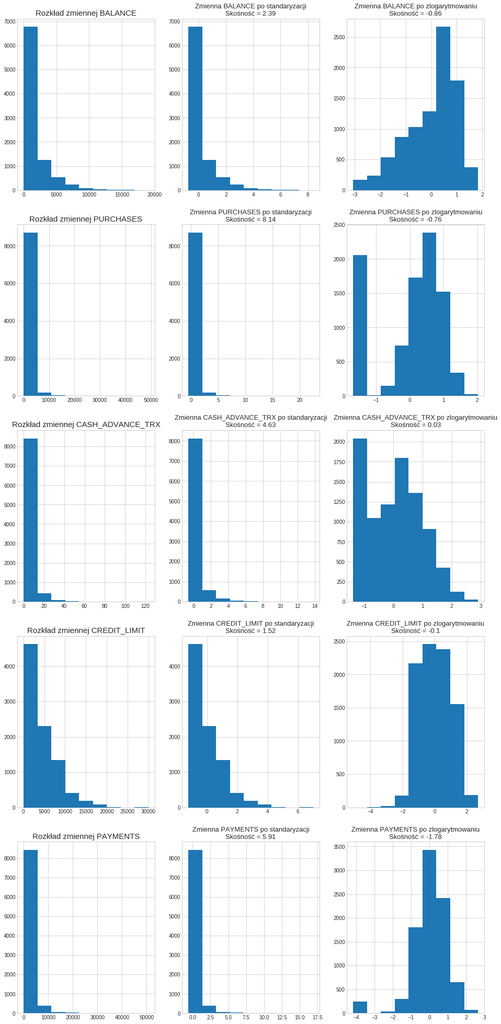

Jak widać nasze podejście sprawdziło się i rozkłady zmiennych są o wiele mniej skośne, co ułatwiło późniejszą klasteryzację.

## Korelacja między zmiennymi

Analizując dane sprawdziliśmy też, czy istnieją zmienne ze sobą skorelowane. Do tego użyjemy algorytmu obliczającego współczynnik korelacji Pearsona dla każdej pary zmiennych:

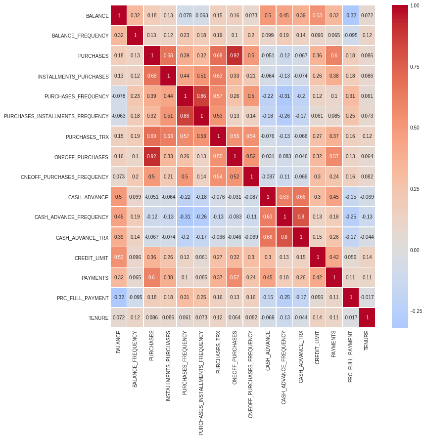

Grafika ukazuje to, czego można było się w dużej mierze spodziewać - zmienne grupują się ze sobą *tematycznie*, to znaczy silniejsze korelacje występują w zmiennych dotyczacych tej samej kwestii, na przykład płatności jednorazowych czy płatności w ratach. Jedynie zmienna *Tenure* (czas trwania aktywnej karty kredytowej użytkownika) nie jest z resztą skorelowana.

Okazuje się, że ma ona bardzo małą wariancje. Postanowiliśmy usunąć ją, oraz trzy inne kolumny o małym znaczeniu.

## Wizualizacja zbioru danych

W celu przedstawienia na grafice dwuwymiarowej zbioru $12$-wymiarowego użyjemy dwóch algorytmów służących do redukcji wymiarów: *PCA* oraz *TSNE*. Porównamy wyniki między wizualizacją zbioru (tylko) wystandaryzowanego a tym, na którym dodatkowo narzuciliśmy przekształcenia zmiennych. Będzie to potwierdzeniem, że użyte logarytmowanie pozytywnie wpłynęło na rozróżnialność rekordów (zauważalne w szczególności przy algorytmie *TSNE*):

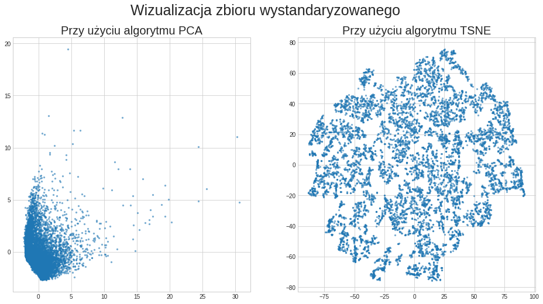

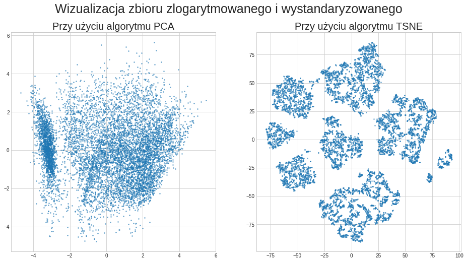

# Analiza skupień

## Agglomerative clustering

Jako pierwszy wypróbujemy algorytm hierarchiczny. Potrzebne jest okreslenie docelowej liczby klastrów, więc przeprowadziliśmy analizę profilu (*silhouette analysis*) w celu jej znalezienia:

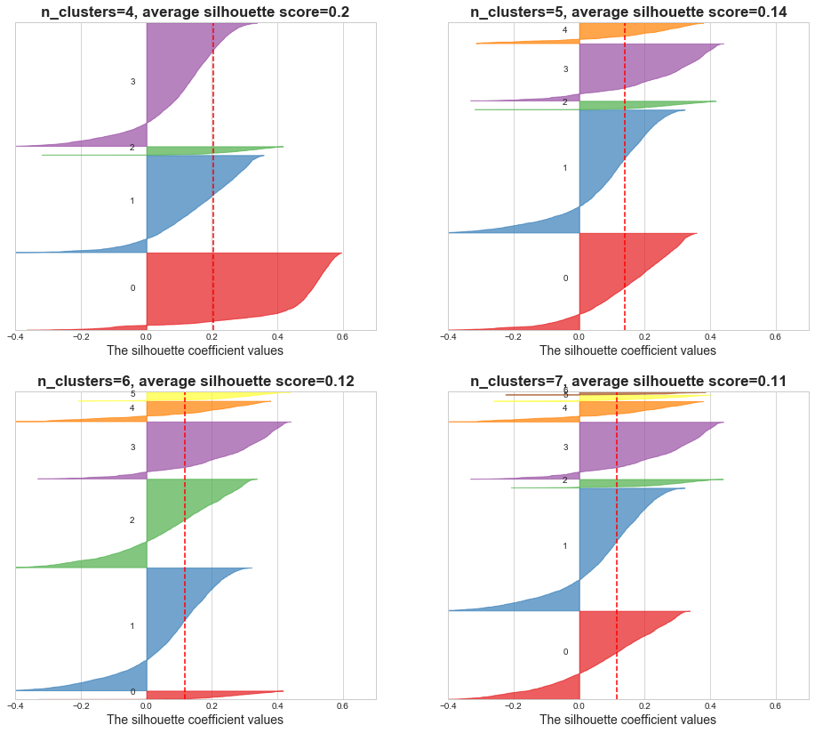

Tak samo jak w przypadku algorytmu *k-means* poruszonego niżej, ograniczyliśmy się do możliwej liczby klastrów między $4$ a $7$. Uważamy, że szukanie klastrów poza tym przedziałem prowadzi do zbyt dużej generalizacji lub wyszczegóławiania rekordów. Poza tym, dla liczby klastrów z przedziału $[4, 7]$ otrzymaliśmy najlepsze wyniki.

Jak widać, najlepszy średni wynik otrzymaliśmy dla $4$ klastrów. Stąd sprawdziliśmy jak wygląda zbiór z nałożonymi kolorami świadczących o klastrach:

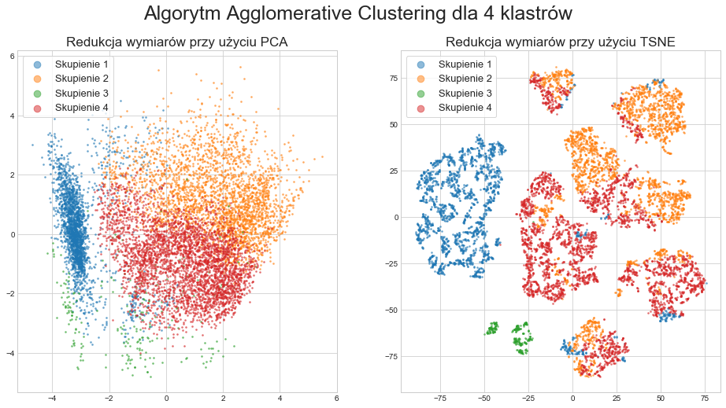

Algorytm ten nie dał jakichś sensownych efektów. Jedynie grupa wydzielająca się na lewo w wizualizacji *PCA* jest ładnie wyodrębniona.

## DBSCAN - algorytm gęstościowy

Drugim testowanym algorytmem jest *DBSCAN*, który ma nieco odmienne podejście do problemu analizy skupień. Dzięki niemu jesteśmy w stanie stwierdzić, czy w naszym zbiorze danych występują gęste skupiska rekordów. Nie zakłada się w nim z góry liczby klastrów. O końcowym efekcie decydują jedynie hiperparametry algorytmu.

Po próbach ich optymalizacji dotarliśmy do efektów na wizualizacjach poniżej - $4$ wydzielone podgrupy wśród wszystkich rekordów. Pozostałe, mimo że traktowane jako osobne skupienie, są efektem klasyfikacji przez *DBSCAN* jako mało ważne, bądź szum dla wydzielonych już klastrów.

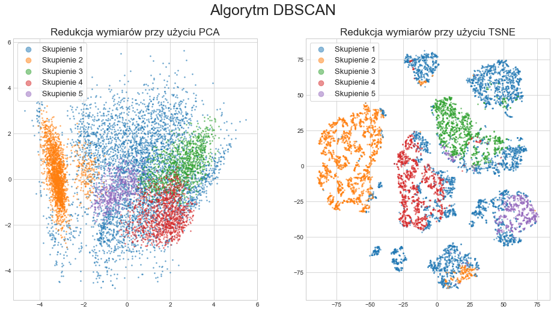

## Algorytm k-means

### Elbow plot

Szukamy najbardziej trafnej liczby klastrów rysując *elbow plot* - wykres, który wskazuje łączną sumę kwadratów odległości punktów od środków swoich klastrów (wykorzystamy do tego algorytm *k-średnich*)

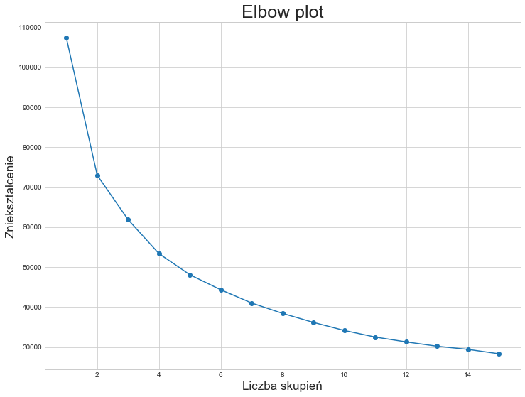

Jak widać powyżej, odpowiedniej liczby nie da się bezpośrednio wyciągnąć z wykresu. Mimo wszystko widać, że linia na wykresie najbardziej zmienia nachylenie dla liczby klastrów z przedziału $[4, 6]$.

### Miara silhouette

Zbadaliśmy też dla jakiej liczby klastrów osiągniemy najlepszy wynik miary silhouette.

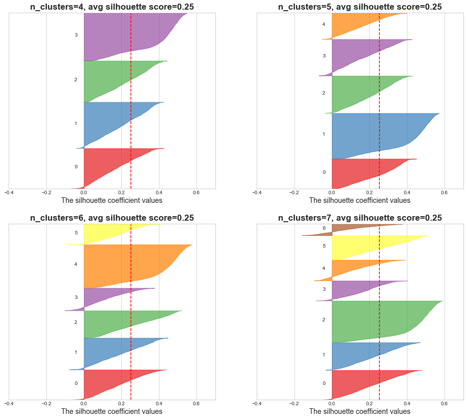

### Końcowy model

Mimo, że średni wynik analizy profilu wychodzi ten sam we wszystkich przypadkach, to najlepiej prezentowuje się liczba klastrów równa $5$:

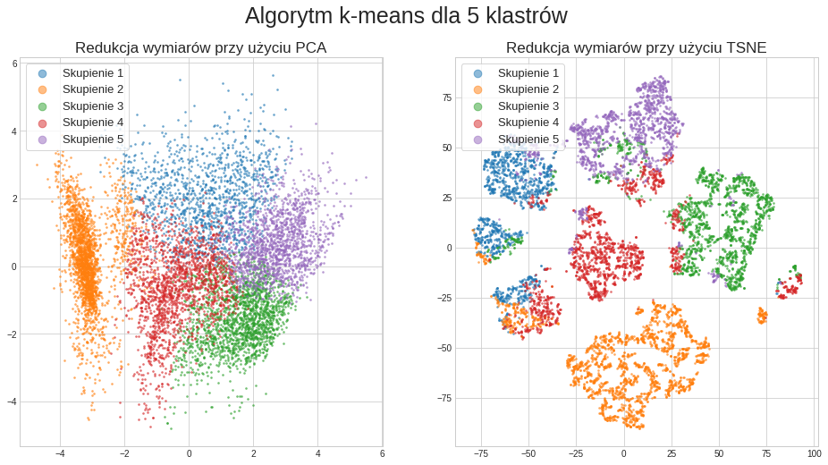

Na powyższych wykresach możemy zaobserwować (mocno rozszerzoną) analogię do wyników otrzymanych z użyciuem algorytmu *DBSCAN*.

## Biplot dla 5 klastrów

W celu ustalenia, które zmienne potencjalnie mają wpływ na pogrupowanie, przygotowaliśmy biplot naszego zbioru z kolorem jako etykiety.

[figure not shown]

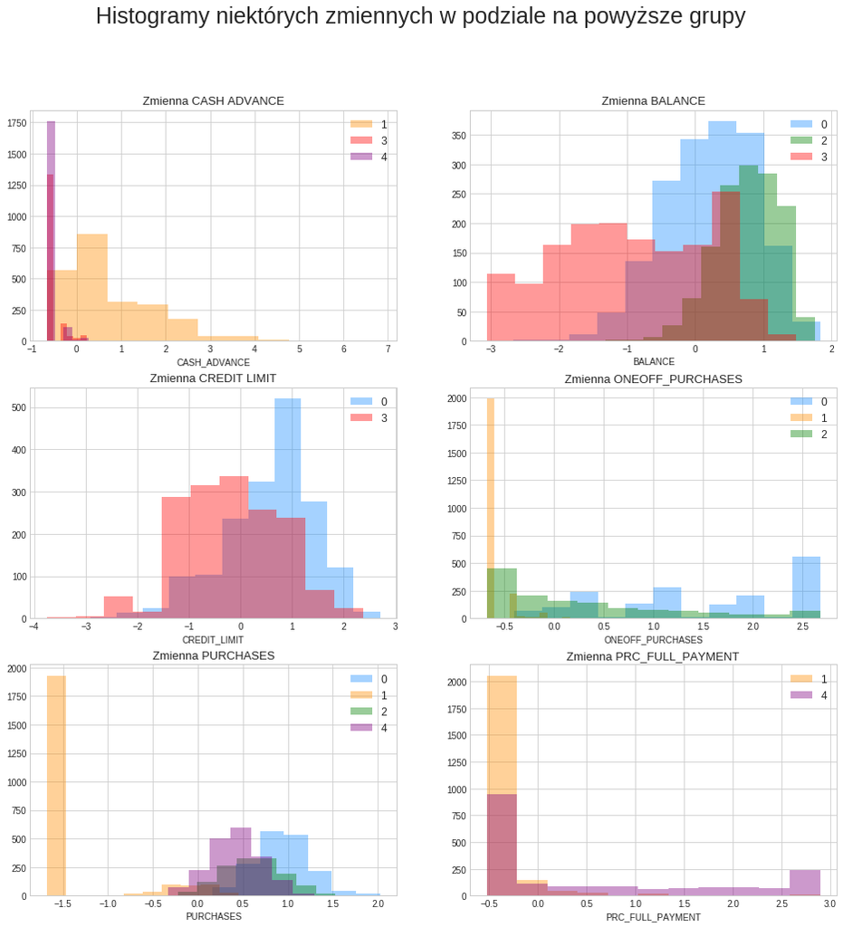

Po powyższym biplocie oraz histogramach widać podstawowe zależności rządzące się tym zbiorem danych.

- Grupa Czerwona wydaje się być nowymi użytkownikami o stosunkowo niskim limicie kredytowym i stanie konta
- Grupa Niebieska posiada dużo pieniędzy na koncie i kupuje drogie rzeczy. Jest to mocno skorelowane z ich limitem kredytowym
- Grupa Zielona wydaje się być najbogatsza. Wykonuje mniej operacji na koncie, ale zawsze spłaca kredyt
- Fioletowi dużo i często kupują. Nie mają problemów z spłacaniem kredytu, w przeciwieństwie do Pomarańczowych
- Pomarańczowi to "martwi użytkownicy". Praktycznie nie korzystają z swojego rachunku, poza kredytami gotówkowymi

Rozkłady zmiennych podajemy w formie wystandaryzowanej, ponieważ normalnie są mocno skośne i mało czytelne.

## PCA w 3D

Dwa komponenty nie zawsze wystarczą nam do wizualizacji. Posiłkując się zaawansowanym narzędziem do analizy modeli do przetwarzania języka naturalnego - *TensorBoard*, stworzyliśmy wizualizację naszego zbioru danych w przestrzeni 3-wymiarowej. Do redukcji wymiarowości ponownie użyliśmy algorytmu *PCA*.

[Wizualizacja naszego zbioru przy użyciu *TensorBoard*](https://projector.tensorflow.org/?config=https://gist.githubusercontent.com/hbaniecki/c510150e38a6518bae1b0d52d0f96a2b/raw/599e5f97e2912c8e81a3d563ab5bd3fd5165ace9/template_projector_config.json)

Poniżej zamieszczamy przykładowe wizualizacje możliwe do osiągnięcia dzięki temu narzędziu:

[figure not shown]

# Końcowe wnioski z projektu i podsumowanie

Zadanie klasteryzacji na takich zbiorach nie musi być trywialne - może się okazać, że nie ma klastrów, które niosłyby jakąś informacje o zbiorze

- Algorytm *agglomerative clustering*, łącząc klastry ze sobą, nie był w stanie poradzić sobie z naszym zadaniem
- Algorytm *DBSCAN*, ukazując najgęstrze skupienia w zbiorze, wyłapuje grupy docelowe i nie musi klasteryzować wszystkich osób
- Algorytm *K-means*, w naszym wypadku, stanowi uzupełnienie klastrów wskazanych przez *DBSCAN*

Finalnie ujawniło się nam 5 grup użytkowników banków, na temat których jesteśmy w stanie stwierdzić jakich klientów zawierają:

- klienci z niskim limitem kredytowym i stosunkowo sporadycznym użyciem konta,
- klienci kupujący najdroższe rzeczy i najczęściej korzystający z karty,
- klienci z największym rachunkiem i zdolnością kredytową,
- przeciętni klienci z średnią liczbą płatności i marginalnymi problemami ze spłacaniem karty,
- "martwi klienci" i/lub wielbiciele kredytów gótówkowych, których nie spłacają.